# Quiz 180523 : Birthday Problem, Matching Problem, Money Illusion

coop711

2018-05-23

## 퀴즈 응답

### Birthday Problem

#### 생일이 같은 사람

|  | 학번 | 생일 | 그룹 |
| --- | --- | --- | --- |
| 77 | 20155267 | 01월17일 | Black |
| 89 | 20125144 | 01월17일 | Red |
| 94 | 20135140 | 01월24일 | Black |
| 137 | 20186276 | 01월24일 | Black |
| 91 | 20183825 | 02월01일 | Red |
| 153 | 20175426 | 02월01일 | Red |
| 13 | 20135204 | 02월06일 | Black |
| 76 | 20145318 | 02월06일 | Red |
| 166 | 20186297 | 02월06일 | Black |
| 80 | 20185132 | 02월15일 | Black |
| 85 | 20185137 | 02월15일 | Red |
| 16 | 20173004 | 03월02일 | Red |
| 38 | 20165118 | 03월02일 | Black |
| 21 | 20186213 | 03월28일 | Red |
| 117 | 20173939 | 03월28일 | Red |
| 33 | 20183616 | 04월03일 | Red |
| 93 | 20176134 | 04월03일 | Red |
| 157 | 20122928 | 04월03일 | Black |
| 102 | 20183828 | 04월07일 | Red |
| 165 | 20185298 | 04월07일 | Black |
| 18 | 20145209 | 04월15일 | Black |
| 50 | 20135118 | 04월15일 | Red |
| 71 | 20163709 | 04월21일 | Red |
| 133 | 20172893 | 04월21일 | Black |
| 131 | 20145336 | 04월25일 | Black |
| 140 | 20125255 | 04월25일 | Red |
| 15 | 20135306 | 04월26일 | Red |
| 172 | 20185303 | 04월26일 | Red |
| 56 | 20144216 | 05월08일 | Black |
| 169 | 20172912 | 05월08일 | Black |
| 12 | 20157031 | 05월11일 | Red |
| 139 | 20186277 | 05월11일 | Black |
| 63 | 20135218 | 06월30일 | Red |
| 178 | 20185304 | 06월30일 | Black |
| 83 | 20185134 | 07월21일 | Red |
| 101 | 20162120 | 07월21일 | Red |
| 59 | 20185235 | 09월28일 | Red |
| 69 | 20172613 | 09월28일 | Black |
| 26 | 20163307 | 10월24일 | Red |
| 103 | 20134343 | 10월24일 | Red |
| 134 | 20153525 | 11월01일 | Black |
| 149 | 20172747 | 11월01일 | Black |
| 64 | 20185240 | 11월16일 | Red |
| 116 | 20181064 | 11월16일 | Red |

#### 어느 날에 몇 명씩 생일이 같은가?

| 01월17일 | 01월24일 | 02월01일 | 02월06일 | 02월15일 | 03월02일 | 03월28일 | 04월03일 | 04월07일 | 04월15일 | 04월21일 | 04월25일 | 04월26일 | 05월08일 | 05월11일 | 06월30일 | 07월21일 | 09월28일 | 10월24일 | 11월01일 | 11월16일 | 계 |
| --- | --- | --- | --- | --- | --- | --- | --- | --- | --- | --- | --- | --- | --- | --- | --- | --- | --- | --- | --- | --- | --- |
| 2 | 2 | 2 | 3 | 2 | 2 | 2 | 3 | 2 | 2 | 2 | 2 | 2 | 2 | 2 | 2 | 2 | 2 | 2 | 2 | 2 | 44 |

#### 생일이 같은 사람은 몇 명 정도 기대되는가?

$N$을 전체 인원이라 할 때, 기대 인원은 $N\times\{1- (\frac{364}{365})^{N-1}\}$로 계산된다. 무응답이거나 결석한 학생을 제외한 응답 인원 $N = 148$명에 대하여 기대인원을 계산하면

```
## [1] 49.1
```

이고, 오차는

[output not shown]

이므로 이론적으로 계산한 값은 관찰된 값과 잘 부합한다.

#### 태어난 달의 분포는?

|  | 1월 | 2월 | 3월 | 4월 | 5월 | 6월 | 7월 | 8월 | 9월 | 10월 | 11월 | 12월 | 계 |
| --- | --- | --- | --- | --- | --- | --- | --- | --- | --- | --- | --- | --- | --- |
| Red | 12 | 3 | 10 | 7 | 5 | 7 | 4 | 5 | 10 | 8 | 4 | 3 | 78 |
| Black | 9 | 4 | 2 | 5 | 9 | 8 | 3 | 6 | 9 | 5 | 7 | 3 | 70 |
| 계 | 21 | 7 | 12 | 12 | 14 | 15 | 7 | 11 | 19 | 13 | 11 | 6 | 148 |

랜덤화 효과 검증

Pearson’s Chi-squared test with simulated p-value (based on 2000 replicates): `.`

| Test statistic | df | P value |
| --- | --- | --- |
| 8.838 | NA | 0.6557 |

월별로 고르게 출생하였는가?

Chi-squared test for given probabilities: `.`

| Test statistic | df | P value |
| --- | --- | --- |
| 18.7 | 11 | 0.06664 |

### Matching Problem

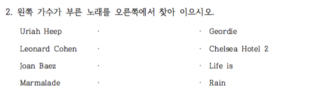

#### 정답갯수의 분포

|  | 0 | 1 | 2 | 4 | 계 |
| --- | --- | --- | --- | --- | --- |
| **Red** | 7 | 15 | 6 | 47 | 75 |
| **Black** | 4 | 8 | 12 | 45 | 69 |
| **계** | 11 | 23 | 18 | 92 | 144 |

#### 카이제곱 적합도 테스트

랜덤하게 골랐다면, 각각의 확률은 9/24, 8/24, 6/24, 1/24임. 응답인원 144명을 각 확률에 곱해보면,

| 0 | 1 | 2 | 4 | 계 |
| --- | --- | --- | --- | --- |
| 54.0 | 48.0 | 36.0 | 6.0 | 144.0 |

Chi-squared test for given probabilities with simulated p-value (based on 2000 replicates): `.`

| Test statistic | df | P value |
| --- | --- | --- |
| 1289 | NA | 0.0004998 * * * |

### 직관과 어긋나는 용어

#### 연비

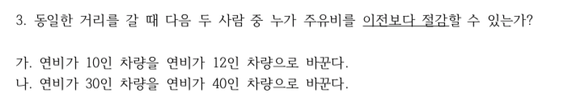

1,200 킬로미터룰 주행한다고 해 보자. ’가’는 120리터에서 100리터로 20리터를 절감하고, ’나’는 40리터에서 30리터로 10리터를 절감하게 된다. 따라서 ’가’운전자가 이전보다 더 절감하게 된다.

|  | 연비 10 => 12 | 연비 30 => 40 | 불참 | 결석 | 계 |
| --- | --- | --- | --- | --- | --- |
| **Red** | 31 | 47 | 0 | 12 | 90 |
| **Black** | 33 | 35 | 2 | 20 | 90 |
| **계** | 64 | 82 | 2 | 32 | 180 |

Pearson’s Chi-squared test with simulated p-value (based on 20000 replicates): `.`

| Test statistic | df | P value |
| --- | --- | --- |
| 1.139 | NA | 0.3182 |

#### % 비교.

| 연비 10 => 12 | 연비 30 => 40 | 계 |
| --- | --- | --- |
| 43.8 | 56.2 | 100.0 |

### 화폐 착각

#### 인플레이션과 임금인상

#### Red

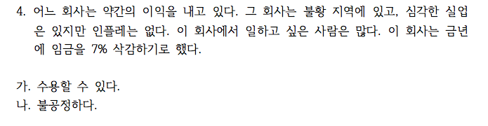

#### Black

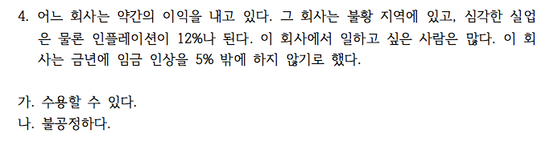

인플레 없이 7%를 삭감하는 것과 12% 인플레 상황에서 5%임금 인상은 동등한 조건인데도 ’임금인상’이라는 말에 ’수용가능하다’는 응답 비율이 늘어남에 유의.

|  | 수용가능 | 불공정 | 불참 | 결석 | 계 |
| --- | --- | --- | --- | --- | --- |
| **실업+인플레0%, 임금삭감7%** | 40 | 38 | 0 | 12 | 90 |
| **실업+인플레12%, 임금인상5%** | 46 | 22 | 2 | 20 | 90 |
| **계** | 86 | 60 | 2 | 32 | 180 |

Pearson’s Chi-squared test with Yates’ continuity correction: `.`

| Test statistic | df | P value |
| --- | --- | --- |
| 3.372 | 1 | 0.06633 |

#### % 비교.

|  | 수용가능 | 불공정 | 계 |
| --- | --- | --- | --- |
| **실업+인플레0%, 임금삭감7%** | 51.3 | 48.7 | 100.0 |
| **실업+인플레12%, 임금인상5%** | 67.6 | 32.4 | 100.0 |